# crisprQTL proof-of-concept experiment in T cells Hit validation

Ximena Ibarra-Soria

30 November, 2023

We have identified deferentially expressed genes after silencing intergenic elements in CD4 T cells. To validate the results, new experiments are performed for four different targets:

```r
## bulk RNA-seq validation of selected hits
files <- list.files(paste0(dir, "data/validation_experiments/Gene"), pattern = "short.txt")

data <- lapply(files, function(x) { read.table(paste0(dir, "data/validation_experiments/Gene/", x),header=1,row.names=1) })
data <- do.call(cbind, data)
colnames(data) <- sub(".trimmomatic.genome.deduplicated.gene_id.exon.ct.short.txt", "", files)

# metadata
meta <- read.table(paste0(dir, "data/validation_experiments/validation_metadata.tsv"), header = TRUE)
meta <- meta[meta$IRMS_Sample_ID %in% colnames(data),]
meta <- meta[match(colnames(data), meta$IRMS_Sample_ID),]

meta$target <- as.factor(meta$target)
meta$target <- relevel(meta$target, ref = "NT")
levels(meta$target)[-1]
```

```
## [1] "CTSC_ENH1"  "HPCAL1_ENH" "KCNN4_ENH"  "PKM_ENH"
```

```r
## annotate gene names
# take from the annotation used by STAR
# zcat Homo_sapiens.GRCh38.96.gtf.gz | grep -w gene | cut -f 9 | cut -d " " -f2,6 > Homo_sapiens.GRCh38.96.ann
gene_ann <- read.table(paste0(dir, "data/validation_experiments/Homo_sapiens.GRCh38.96.ann"))[,c(1,3)]
colnames(gene_ann) <- c("id", "name")
```

Instead of silencing the elements, this time we use CRISPRn with two gRNAs flanking the putative enhancer to induce a deletion. The perturbed cells are then sequenced in bulk to assess transcriptional changes. Experiments are done using cells from two different donors. Two non-targeting controls are also included to serve as controls.

### Differential expression analysis

We use `edgeR` to test for differences in expression levels between the edited cells and those with NT control gRNAs.

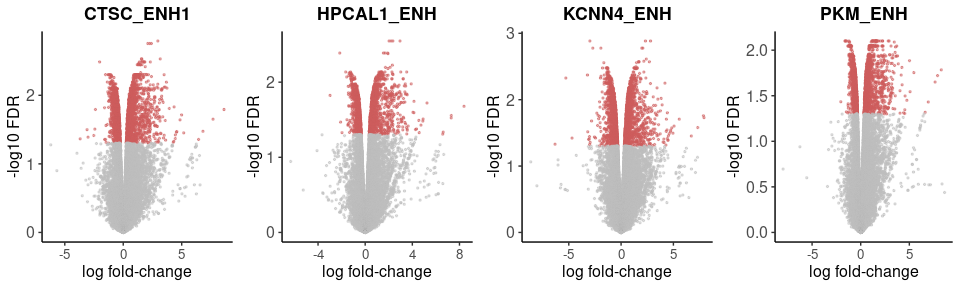

```r
## test each perturbation against NT controls
# also consider only genes within 1Mb as done in the screen
gene_gRNA_pairs <- readRDS(paste0(dir, "results/04_gene_gRNA_pairs.Rds"))
gRNA_ann <- read.table(paste0(dir, "data/gRNA_library.tsv"), sep="\t", header = TRUE)
gene_gRNA_pairs$target <- gRNA_ann[match(gene_gRNA_pairs$gRNA_id, gRNA_ann$ID),'target']
gene_gRNA_pairs <- unique(gene_gRNA_pairs[,c(1,3)])
gene_gRNA_pairs$id <- gene_ann[match(gene_gRNA_pairs$gene_id, gene_ann$name), 'id']

## edgeR object
y <- DGEList(data, samples=meta)
# remove lowly expressed genes
y <- y[filterByExpr(y, group=y$samples$target),]
# estimate size factors
y <- calcNormFactors(y)
# normalised data
data.cpm <- cpm(y, log = TRUE)


edger <- list()
plots <- list()
for(target in levels(y$samples$target)[-1]){
  # subset
  y.sub <- y[,y$samples$target %in% c(target, "NT")]
  y.sub$samples$target <- droplevels(y.sub$samples$target)
  y.sub$samples$target <- relevel(y.sub$samples$target, ref="NT")

  # design
  design <- model.matrix(~target, y.sub$samples)

  # fit model
  y.sub <- estimateDisp(y.sub, design)
  fit <- glmQLFit(y.sub, design, robust = TRUE)

  edger[[target]] <- as.data.frame(topTags(glmQLFTest(fit), n=Inf))
  edger[[target]]$target <- target

  # add gene names
  edger[[target]]$gene <- gene_ann[match(row.names(edger[[target]]), gene_ann$id),'name']

  # flag genes in the +-1Mb neighbourhood
  genes <- intersect(gene_gRNA_pairs[gene_gRNA_pairs$target == target,]$id, row.names(y$counts))
  edger[[target]]$cis <- row.names(edger[[target]]) %in% genes

  # reorder columns and sort
  edger[[target]] <- edger[[target]][,c(6:8, 1:5)]
  edger[[target]] <- edger[[target]][order(-edger[[target]]$cis, edger[[target]]$FDR),]

  # volcano plot
  plots[[target]] <- ggplot(edger[[target]], aes(logFC, -log10(FDR), colour=FDR < 0.05)) +
    geom_point(size=0.5, alpha=0.5) +
    scale_color_manual(values = c("grey", "indianred")) +
    ggtitle(target) +
    xlab("log fold-change") +
    ylab("-log10 FDR") +
    th + labs(colour="DEG") +
    guides(colour = guide_legend(override.aes = list(size=0.75)))
}
ggarrange(plotlist = plots, ncol=4, nrow=1, legend = "none")
```

### Validation of expected genes

We check whether the gene we identified as DE form the single-cell experiments is recapitulated. Three out of the four perturbations show significant dowregulation of the expected gene.

```r
expected <- rbind(edger[['CTSC_ENH1']][edger[['CTSC_ENH1']]$gene == "CTSC",],
                  edger[['HPCAL1_ENH']][edger[['HPCAL1_ENH']]$gene == "HPCAL1",],
                  edger[['KCNN4_ENH']][edger[['KCNN4_ENH']]$gene == "KCNN4",],
                  edger[['PKM_ENH']][edger[['PKM_ENH']]$gene == "PKM",])
expected[order(expected$FDR),]
```

|  | target | gene | cis | logFC | logCPM | F | PValue | FDR |
| --- | --- | --- | --- | --- | --- | --- | --- | --- |
| ENSG00000109861 | CTSC_ENH1 | CTSC | TRUE | -0.3971774 | 7.225263 | 32.440575 | 0.001643771 | 0.01888646 |
| ENSG00000067225 | PKM_ENH | PKM | TRUE | -0.4589847 | 11.430490 | 20.197600 | 0.004172798 | 0.03698556 |
| ENSG00000115756 | HPCAL1_ENH | HPCAL1 | TRUE | -0.4720598 | 6.337765 | 20.026932 | 0.004410062 | 0.04017257 |
| ENSG00000104783 | KCNN4_ENH | KCNN4 | TRUE | -0.1376707 | 4.524061 | 1.172519 | 0.317744841 | 0.49608763 |

Although `KCNN4_ENH` doesn’t reach statistical significance, we do observe the expected downregulation but the variability between donors is larger than the perturbation effect. It is likely that with a larger number of donors this effect would be validated.

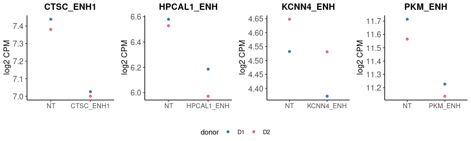

```r
plots <- list()
for(target in levels(meta$target)[-1]){
  id <- gene_ann[gene_ann$name == meta[meta$target==target,'expected_gene'],'id']
  df <- meta[meta$target %in% c(target, "NT"),]
  df$expr <- as.numeric(data.cpm[id, df$IRMS_Sample_ID])

  plots[[target]] <- ggplot(df, aes(target, expr, colour=donor)) +
    geom_point() +
    scale_color_manual(values = as.character(GetColors(n=2, scheme="bright"))) +
    xlab("") +
    ylab("log2 CPM") +
    ggtitle(target) +
    th
}

ggarrange(plotlist = plots, ncol=4, nrow=1, common.legend = TRUE, legend = "bottom")
```

### Conclusions

Based on these results, we can conclude that the effects discovered in the single-cell crisprQTL screen are indeed the result of inactivating the putative enhancers. The changes are reproducible in two independent donors.

```r
## save
write.table(data.cpm, paste0(dir, "results/08_validation_experiment_CPMexpr.tsv"), quote = FALSE, sep="\t")

saveRDS(edger, paste0(dir, "results/08_validation_experiment_edgeR.Rds"))
for(target in names(edger)){
  write.table(edger[[target]], paste0(dir, "results/08_validation_experiment_edgeR_", target, ".tsv"), quote = FALSE, sep="\t")
}
```